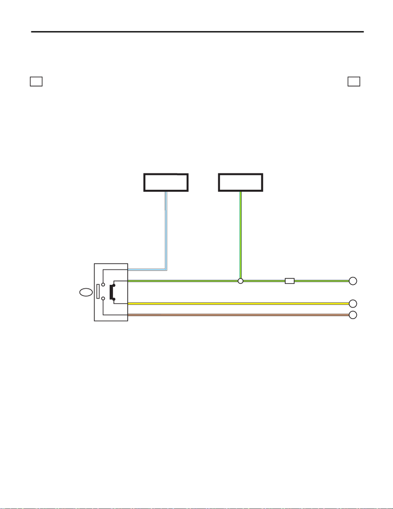

WI-137

Cruise Control System

WIRING SYSTEM

15.Cruise Control System

A: WIRING DIAGRAM

1. ENGINE TYPE FA

WI-44339

1a 1a

BR/W

C

W/L

G/Y

W/L

G/Y

B65

2

Y Y

G/Y

4

B

A

3

1

BR/W

MT

FB-3

F/B FUSE NO. 8

(B)

STOP LIGHT &

BRAKE SWITCH

FB-32

F/B FUSE NO. 4

(IG)

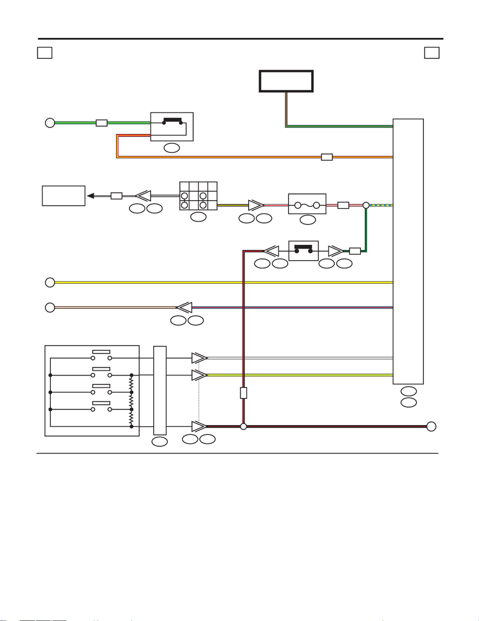

WI-138

Cruise Control System

WIRING SYSTEM

SET/-

ECM

WI-44340

1b 1b

B134

A:

E158

B:

11

7

12

11

4

G/R

L/R B8

G/R A32

R/Y A34

A43Y

8226

9

W/R

B/R

R/W A33

1

BR/W

Y

B

G/Y G/Y 1

R/Y 2

A

C

T7

B107

PR

N

D

B/Y

B12T3

T3B12

L/RBR/W

E3B22

A20

A6Y/L

W

CRUISE

RES/+

CANCEL

4

3

9

B68

W

Y/L

B/R

B/R

ST1

ST3

B/R

D

MT

CVT

MT

1

10A

B550

CVT

12

MT

MT

1

2

T2 B25T2B25

ROLL

CONNECTOR

CRUISE CONTROL SWITCH

INHIBITOR SWITCH

CLUTCH SWITCH

REF. TO

STARTER

SYSTEM [1a] [2a]

FB-38

F/B FUSE NO. 12

(IG)

G/B

NEUTRAL POSITION

SWITCH 1

FUSE HOLDER

: MT MODEL : G/B

CVT MODEL : R/W

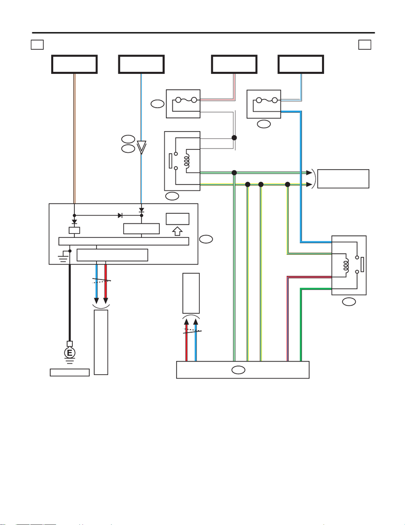

WI-139

Cruise Control System

WIRING SYSTEM

ECM

WI-44341

1c 1c

3

A:

B134

W

W12

11

LG

Y/L10

13

Y/L

R/L

G

L15

16

17

14

W

W/R2

15

15A

15A

R

L32

33

38

B

I/F

BR/W20

W/L W/L W/L

BR/W

W/L40

TFT

B550

B550

B220

i10

B225

R/LA39

GA11

R

LA9

A10

LGA38

Y/LA12

Y/LA24

L

W/L3

17

B551

i229

W/L

W/R

MB-24

SBF-7

(B)

MB-23

SBF-7

(B)

FB-18

F/B FUSE NO. 7

(B)

REF. TO ENGINE

ELECTRICAL SYSTEM

[1f] [2f]

REF. TO CAN COMMUNICATION

SYSTEM [b]

REF. TO CAN

COMMUNICATION

SYSTEM [a]

ELECTRONIC THROTTLE

CONTROL RELAY

COMBINATION

METER

MAIN RELAY

FUSE HOLDER

FUSE HOLDER

POWER SUPPLY

CIRCUIT

MICRO COMPUTER

CAN TRANSCEIVER &

RECEIVER

FB-12

F/B FUSE NO. 2

(IG)

REF. TO GND [e]

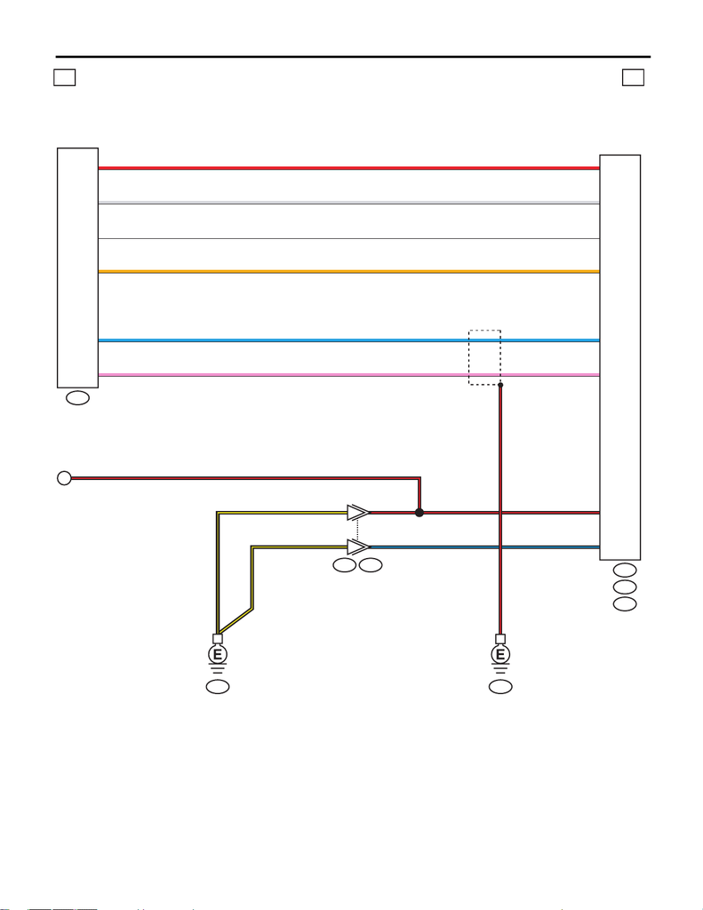

WI-140

Cruise Control System

WIRING SYSTEM

WI-44342

1d 1d

C:

E159

A:

B134

B:

E158

E57

16

15

E3 B22

C2

RC1

W

GR B18

A35B/L

A47B/R

B/R

O B30

P B29

L B17

D

B/R

3

6

2

5

4

B/Y

B/Y

1

W

GR

R

O

L

P

B/Y

B/R

B/Y

B/L

ECM

GE-1 GE-2

ELECTRONIC THROTTLE

CONTROL

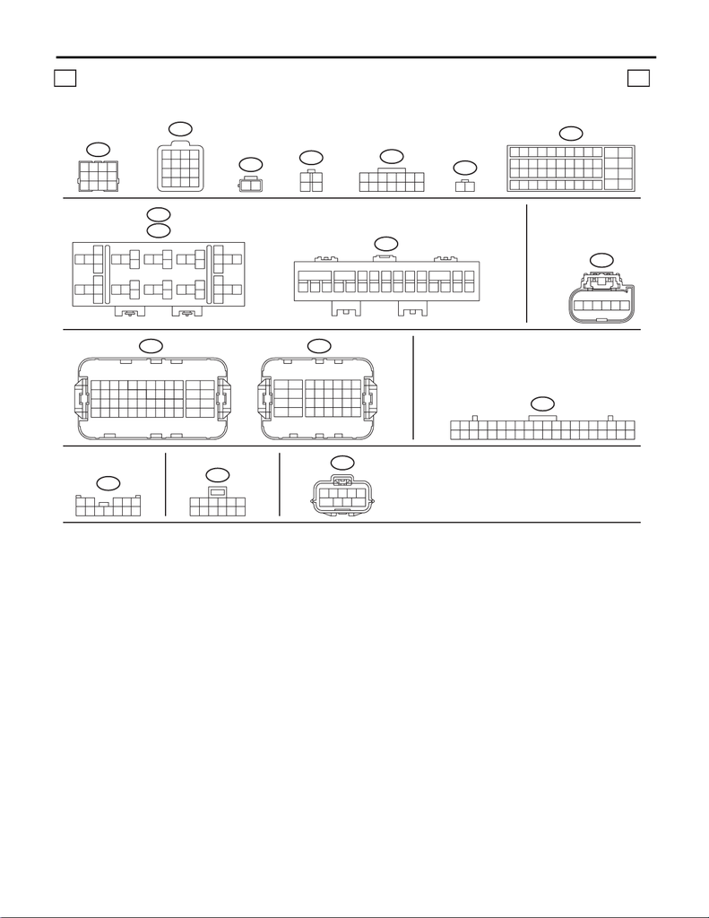

WI-141

Cruise Control System

WIRING SYSTEM

LIST OF CONNECTORS

RELAY HOLDER FUSE HOLDER

1e 1e

(B)

E57

B22

i10

B12

B134A:

(B)

T7

B550

B65

B68

B220

B225

(B)

(

B

)

(

BR

)

B25

(

BR

)

B107

(

L

)

(

B

)

(

B

)

i229

(

BR

)

B:

E158

5

9

1

6

10

2

7

11

3

8

12

4

12

3

4

5678

9

10 11 12

1413 15 16

12

12

34

3

42

156

7

13 1411

12

9

10

8

12

10

11 12

23 24

35 36

47 48

3

5

6

7894

12

45

21

33

3431 3229 3027 2825 26

10 11

12

13

14 15

16

18

19 21 22

20

17

24

5

3

17

9

8

6

32 33

34

35

28262423

25

27

29

30

31

36 37

38

40

41 43 44

42

39

91

2

4

13

12

17

3

16

6

15

587

14

10 11

123456

79

10

85

23

11 12

6

19 21 222017

24

35 36

47 48

18

31 33 343229 30

43 45 464441 42

3412

15 1613 14

27 2825 26

39 4037 38

11 12

9

10

7856341

2

15 1613 14 19

18

20

21 22 23 24 26

25

17

12 345

6789

10 11 12

1

78

69

2345

2

1

89

5

12

6

7

34

1110

5

7

8

6

3

9

12

4

13

15

16

14

11

10

17 18

25 26

12

21

23

24

22

19 20

29

31

32

30

27 28

E159

(GR)

C:

ST3

WI-44343

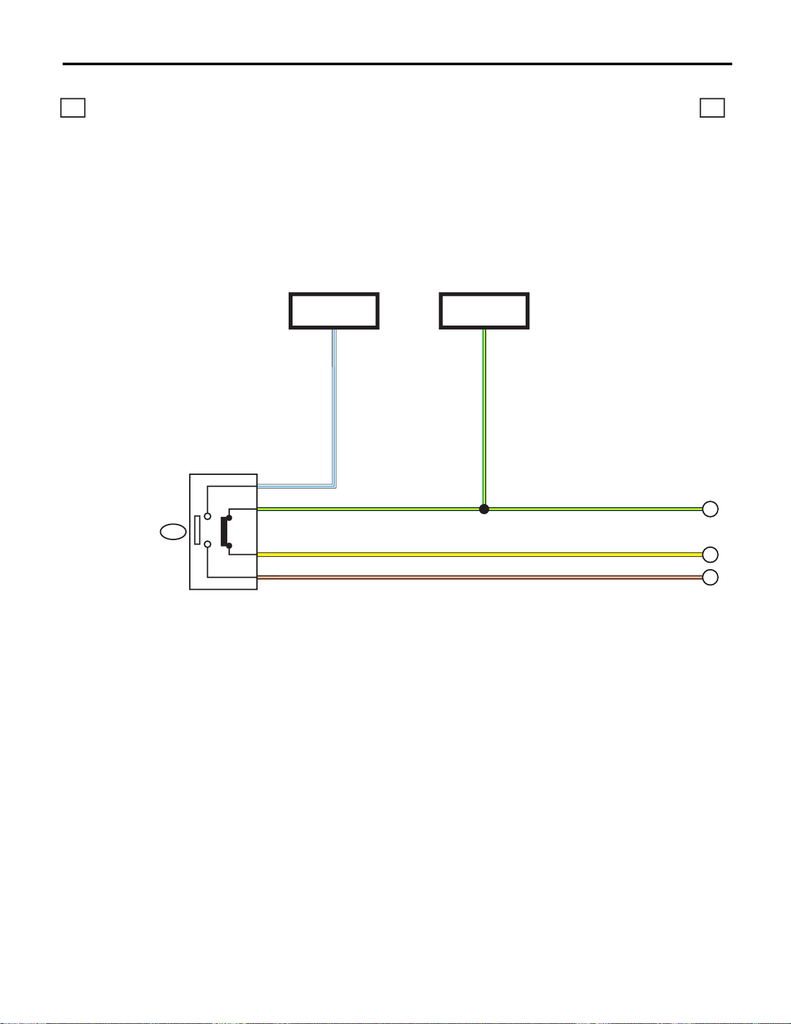

WI-142

Cruise Control System

WIRING SYSTEM

2. ENGINE TYPE EJ

WI-44344

2a 2a

BR/W

C

W/L

G/Y

W/L

G/Y G/Y

B65

2

Y Y4

B

A

3

1

BR/W

FB-3

F/B FUSE NO. 8

(B)

STOP LIGHT &

BRAKE SWITCH

FB-32

F/B FUSE NO. 4

(IG)

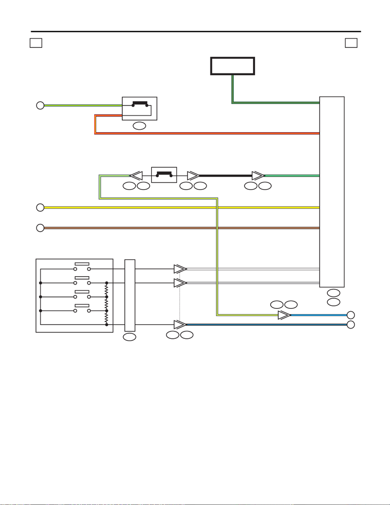

WI-143

Cruise Control System

WIRING SYSTEM

SET/-

ECM

WI-44345

2b 2b

B135

B:

B136

C:

12

11

4

G/R

BR/W C3

G/R C30

C15Y

BR/W

Y

B

C

C13

C12GR/W

W

CRUISE

RES/+

CANCEL

4

3

9

B68

W

GR/W

B/L

ST1

ST3

B/L

LLG/Y

E

D

R/Y B9

G/Y G/Y 1

R/Y 2

A

B107

CLUTCH SWITCH

212

NEUTRAL POSITION

SWITCH 1

B128T9

5

B128T9

T12T2T2T12

ROLL

CONNECTOR

CRUISE CONTROL SWITCH

FB-38

F/B FUSE NO. 12

(IG)

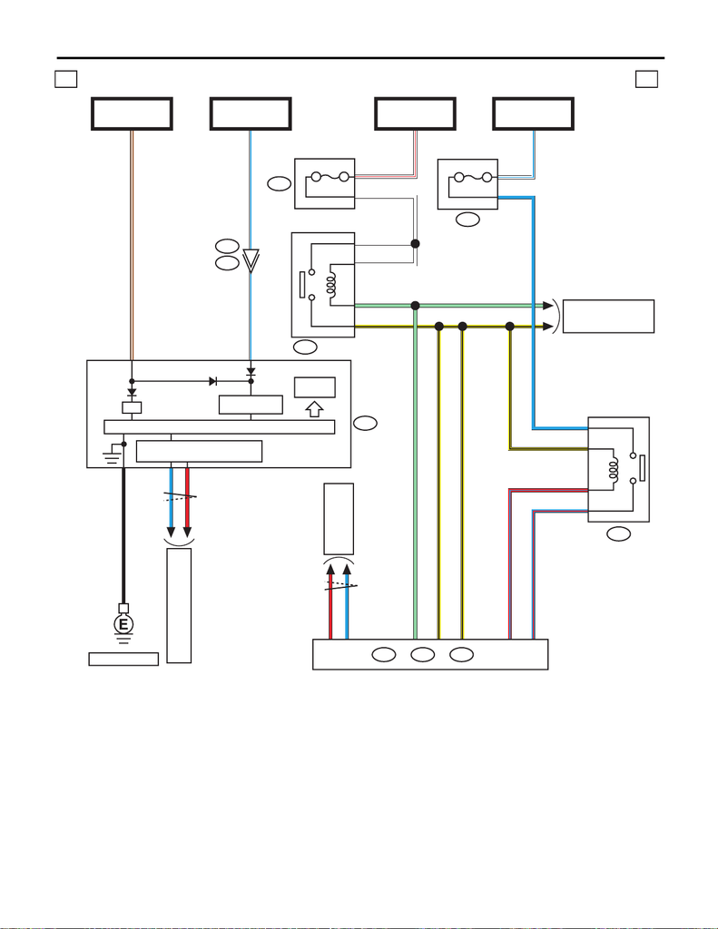

WI-144

Cruise Control System

WIRING SYSTEM

ECM

WI-44346

2c 2c

3

C:

B136

D:

B137

B:

B135

W

W12

11

LG

Y/B10

13

Y/B

R/L

L/R

L15

16

17

14

W

W/R2

19

15A

15A

R

L32

33

38

B

I/F

BR/W20

W/L W/L W/L

BR/W

W/L40

TFT

B550

B550

B220

i10

B225

R/LB17

L/RB7

R

LC28

C17

LGB13

Y/BC1

Y/BD7

L

W/L4

18

B551

i229

W/L

W/R

MB-24

SBF-7

(B)

MB-23

SBF-7

(B)

FB-18

F/B FUSE NO. 7

(B)

REF. TO ENGINE

ELECTRICAL SYSTEM

[3e] [4e]

REF. TO CAN COMMUNICATION

SYSTEM [b]

REF. TO CAN

COMMUNICATION

SYSTEM [a]

ELECTRONIC THROTTLE

CONTROL RELAY

COMBINATION

METER

MAIN RELAY

FUSE HOLDER

FUSE HOLDER

POWER SUPPLY

CIRCUIT

MICRO COMPUTER

CAN TRANSCEIVER &

RECEIVER

FB-12

F/B FUSE NO. 2

(IG)

REF. TO GND [e]

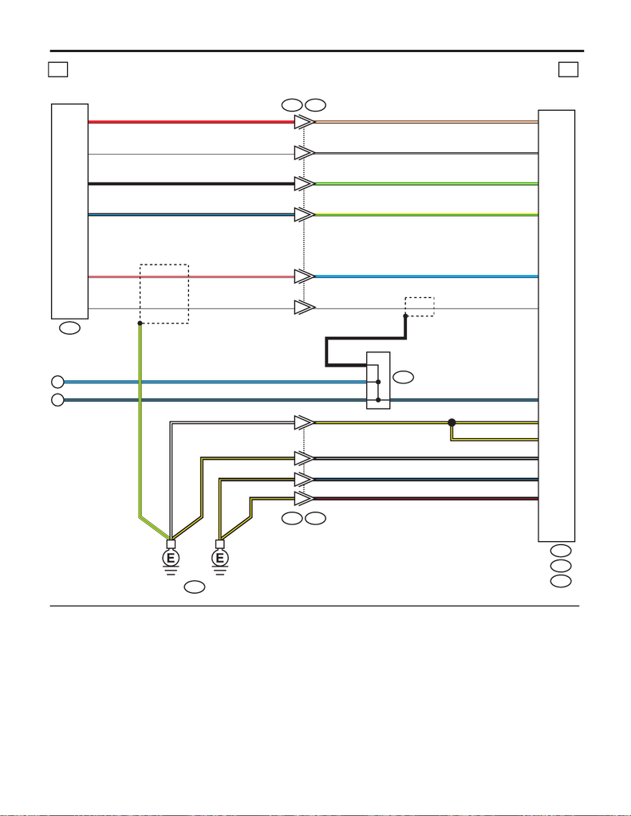

WI-145

Cruise Control System

WIRING SYSTEM

1

WI-44347

2d 2d

D:

B137

A:

B134

C:

B136

E57

40

34

E2 B21

A2

A19

A1

D1B/W

A4B/Y

D3B/Y

C4B/L

A29

W A18

L A28

E

D

B/L B/L

LL

1

1

1

1

3

2

1

5

4

B/W

Y/G

B/Y

6

B

W

R

B/L

W/R

W

B

W

R

B/L

W/R

W

G/Y

W/B

BR/W

Y/G

G/Y

W/B

BR/W

Y/G

L

W

S

B/W

B/Y

B/Y

B/W

GE-3

B/Y

B/Y

B/L

B/R

B/L

B/R

A6

A3

28

39

38

6

25

24

E2 B21

36

35

B122

ELECTRONIC THROTTLE

CONTROL

: TERMINAL No. OPTIONAL ARRANGEMENT

J/C

ECM

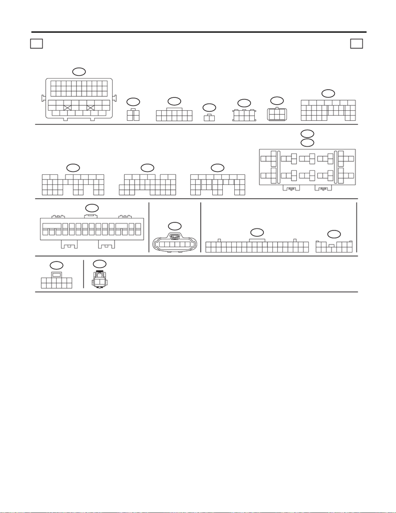

WI-146

Cruise Control System

WIRING SYSTEM

LIST OF CONNECTORS

RELAY HOLDER

FUSE HOLDER

2e 2e

(B)

E57

(B)

B21

i229

i10

B134A:

B550

B220

B225

B135B:

B136C:

(

B

)

123456789

10 11

12 13 14 15 16 17 18 19 20 21 22

23 24 25 26 27 28 29 30 31 32 33

34 35

42 43

36 37 38 39

48 49 50 51 52 53 54

40 41

44 45 46 47

18

23

26

24

25

28 29 3332 3430 31

98

15

1413121110

17

16

1234567

5672134

29

10 11 12 13 14 15

2524

16

30

98

17 18 19

20

28

21 22 23

3231

26 27

33 34 35

19

18

21

20

2322 24 25 26

17

1

23

4

56

27

28 29 30

31 32 33 34 35

798

151413121110 16

10 11

12

13

14 15

16

18

19 21 22

20

17

24

5

3

17

9

8

6

32 33

34

35

28262423

25

27

29

30

31

36 37

38

40

41 43 44

42

39

101

5

14

13

18

432

17

7

16

698

15

11 12

321654

11 12

9

10

7856341

2

15 1613 14 19

18

20

21 22 23 24 26

25

17

12 345

6789

10 11 12

ST3

2

1

89

5

12

6

7

34

1110

WI-44348

B137D:

19

18

20 21

22

23

26

24

25

27

28 29

30 31

98

15

1413121110

17

16

1234567

(B)

B65

12

34

B68

3

42

156

7

13 1411

12

9

10

8

(L)

B107

12

B122

78

5

6

34

21

(BR)

T12

12

123

456

B128

(GR)

[figure not shown]

WI-147

Cruise Control System

WIRING SYSTEM